# Text Analysis of Federal Open Market Committee and CBRT Monetary Policy Committee Statements

Machine Learning in Economics

Alican Yıldırım

```r
library(tm)
library(qdap)
```

```r
FOMC_2017 <- read_docx("FOMC (04.2017).docx")
FOMC_2017
```

```
##  [1] "Information received since the Federal Open Market Committee met in February indicates that the labor market has continued to strengthen and that economic activity has continued to expand at a moderate pace. Job gains remained solid and the unemployment rate was little changed in recent mon…
##  [2] "Market-based measures of inflation compensation remain low; survey-based measures of longer- term inflation expectations are little changed, on balance."
##  [3] "Consistent with its statutory mandate, the Committee seeks to foster maximum employment and price stability. The Committee expects that, with gradual adjustments in the stance of monetary policy, economic activity will expand at a moderate pace, labor market conditions will strengthen somew…
##  [4] "In view of realized and expected labor market conditions and inflation, the Committee decided to raise the target range for the federal funds rate to 3/4 to 1 percent. The stance of monetary policy remains accommodative, thereby supporting some further strengthening in labor market conditio…
##  [5] "In determining the timing and size of future adjustments to the target range for the federal funds rate, the Committee will assess realized and expected economic conditions relative to its objectives of maximum employment and 2 percent inflation. This assessment will take into account a wid…
##  [6] "(more)"
##  [7] " "
##  [8] "- 2 -"
##  [9] "of inflation pressures and inflation expectations, and readings on financial and international developments. The Committee will carefully monitor actual and expected inflation developments relative to its symmetric inflation goal. The Committee expects that economic conditions will evolve i…
## [10] "The Committee is maintaining its existing policy of reinvesting principal payments from its holdings of agency debt and agency mortgage-backed securities in agency mortgage-backed securities and of rolling over maturing Treasury securities at auction, and it anticipates doing so until norma…
## [11] "Voting for the FOMC monetary policy action were: Janet L. Yellen, Chair; William C. Dudley, Vice Chairman; Lael Brainard; Charles L. Evans; Stanley Fischer; Patrick Harker; Robert S. Kaplan; Jerome H. Powell; and Daniel K. Tarullo. Voting against the action was Neel Kashkari, who preferred …
## [12] "- 0 -"
## [13] " "
## [14] "Decisions Regarding Monetary Policy Implementation"
## [15] "The Federal Reserve has made the following decisions to implement the monetary policy stance announced by the Federal Open Market Committee in its statement on March 15, 2017:"
## [16] "•The Board of Governors of the Federal Reserve System voted unanimously to raise the interest rate paid on required and excess reserve balances to 1.00 percent, effective March 16, 2017."
## [17] "•As part of its policy decision, the Federal Open Market Committee voted to authorize and direct the Open Market Desk at the Federal Reserve Bank of New York, until instructed otherwise, to execute transactions in the System Open Market Account in accordance with the following domestic poli…
## [18] "\"Effective March 16, 2017, the Federal Open Market Committee directs the Desk to undertake open market operations as necessary to maintain the federal funds rate in a target range of 3/4 to 1 percent, including overnight reverse repurchase operations (and reverse repurchase operations with…
## [19] "$30 billion per day."
## [20] "The Committee directs the Desk to continue rolling over maturing Treasury securities at auction and to continue reinvesting principal payments on all agency debt and agency mortgage-backed securities in agency mortgage-backed securities. The Committee also directs the Desk to engage in doll…
## [21] "More information regarding open market operations may be found on the Federal Reserve Bank of New York’s website."
## [22] "•In a related action, the Board of Governors of the Federal Reserve System voted unanimously to approve a 1/4 percentage point increase in the primary credit rate to 1.50 percent, effective March 16, 2017. In taking this action, the Board approved requests to establish that rate submitted b…
## [23] "This information will be updated as appropriate to reflect decisions of the Federal Open Market Committee or the Board of Governors regarding details of the Federal Reserve’s operational tools and approach used to implement monetary policy."
```

Notice that each paragraph in the document is a distinct element of the character vector `FOMC_2017`. It needs to be a character vector with a single element which contains the whole text:

```r
FOMC_2017 <- paste(FOMC_2017, collapse = ' ')
FOMC_2017
```

```
## [1] "Information received since the Federal Open Market Committee met in February indicates that the labor market has continued to strengthen and that economic activity has continued to expand at a moderate pace. Job gains remained solid and the unemployment rate was little changed in recent mont…
```

Below we calculate the top 5 most frequent words with the `qdap::freq_terms()` function:

```r
freq.terms <- freq_terms(FOMC_2017, 5)
freq.terms
```

```
##   WORD FREQ
## 1 the    66
## 2 to     37
## 3 of     36
## 4 and    31
## 5 in     22
```

Not surprisingly, the frequently used terms consist of prepositions, pronouns etc., which convey no useful information. When analyzing text data, we need to get rid of unnecessary words so that we are left with proper nouns and the like, which are of primary interest. To do that, we can use `tm::stopwords()`.

```r
freq.terms.2 <- freq_terms(FOMC_2017, 5, stopwords = stopwords("en"))
freq.terms.2
```

```
##   WORD      FREQ
## 1 federal     21
## 2 committee   15
## 3 market      15
## 4 inflation   13
## 5 rate        13
```

Below are the English `stopwords`:

```r
stopwords("en")
```

```
##   [1] "i"          "me"         "my"         "myself"     "we"
##   [6] "our"        "ours"       "ourselves"  "you"        "your"
##  [11] "yours"      "yourself"   "yourselves" "he"         "him"
##  [16] "his"        "himself"    "she"        "her"        "hers"
##  [21] "herself"    "it"         "its"        "itself"     "they"
##  [26] "them"       "their"      "theirs"     "themselves" "what"
##  [31] "which"      "who"        "whom"       "this"       "that"
##  [36] "these"      "those"      "am"         "is"         "are"
##  [41] "was"        "were"       "be"         "been"       "being"
##  [46] "have"       "has"        "had"        "having"     "do"
##  [51] "does"       "did"        "doing"      "would"      "should"
##  [56] "could"      "ought"      "i'm"        "you're"     "he's"
##  [61] "she's"      "it's"       "we're"      "they're"    "i've"
##  [66] "you've"     "we've"      "they've"    "i'd"        "you'd"
##  [71] "he'd"       "she'd"      "we'd"       "they'd"     "i'll"
```

[output cut: 20 more lines]

# Building the Corpus

Now we can import `FOMC_2020` and combine it with `FOMC_2017`:

```r
FOMC_2020 <- read_docx("FOMC (03.2020).docx")
FOMC_2020 <- paste(FOMC_2020, collapse = ' ')
corpus <- c(FOMC_2017, FOMC_2020)
str(corpus)
```

```
##  chr [1:2] "Information received since the Federal Open Market Committee met in February indicates that the labor market ha"| __truncated__ ...
```

The `corpus` object is not a corpus yet, it is just a character vector with length 2.

There are two corpus types: permanent corpus, `PCorpus` and volatile corpus, `VCorpus`. The difference essentially lies in where the data is stored on the computer. `VCorpus` objects use the computer’s RAM, which makes them more efficient to work with. Before building a corpus, the source of our documents needs to be specified (in this case they are stored in a vector). `tm::VectorSource()` function can be used for that purpose:

```r
source <- VectorSource(corpus) #specify the source
FOMC <- VCorpus(source) #create a VCorpus object
str(FOMC)
```

```
## List of 2
##  $ 1:List of 2
##   ..$ content: chr "Information received since the Federal Open Market Committee met in February indicates that the labor market ha"| __truncated__
##   ..$ meta   :List of 7
##   .. ..$ author       : chr(0)
##   .. ..$ datetimestamp: POSIXlt[1:1], format: "2022-05-24 12:50:27"
##   .. ..$ description  : chr(0)
##   .. ..$ heading      : chr(0)
##   .. ..$ id           : chr "1"
##   .. ..$ language     : chr "en"
##   .. ..$ origin       : chr(0)
##   .. ..- attr(*, "class")= chr "TextDocumentMeta"
##   ..- attr(*, "class")= chr [1:2] "PlainTextDocument" "TextDocument"
##  $ 2:List of 2
##   ..$ content: chr "The Federal Reserve is committed to using its full range of tools to support the U.S. economy in this challengi"| __truncated__
##   ..$ meta   :List of 7
##   .. ..$ author       : chr(0)
##   .. ..$ datetimestamp: POSIXlt[1:1], format: "2022-05-24 12:50:27"
##   .. ..$ description  : chr(0)
##   .. ..$ heading      : chr(0)
##   .. ..$ id           : chr "2"
##   .. ..$ language     : chr "en"
##   .. ..$ origin       : chr(0)
##   .. ..- attr(*, "class")= chr "TextDocumentMeta"
##   ..- attr(*, "class")= chr [1:2] "PlainTextDocument" "TextDocument"
##  - attr(*, "class")= chr [1:2] "VCorpus" "Corpus"
```

`VectorSource()` basically identifies the source of the documents, so that when we create a corpus object, the function `VCorpus()` treats each element in the `corpus` vector as separate documents. Thus, the resulting corpus has two documents. We can reach out to the content of a particular document:

```r
FOMC[[2]]$content
```

```
## [1] "The Federal Reserve is committed to using its full range of tools to support the U.S. economy in this challenging time, thereby promoting its maximum employment and price stability goals. The coronavirus outbreak is causing tremendous human and economic hardship across the United States and …
```

# Term-Document Matrix

We can now create the *Term-Document Matrix* (TDM), which has words (terms) in its rows and documents in its columns. We can obtain the TDM using `tm::TermDocumentMatrix()`:

```r
tdm <- TermDocumentMatrix(FOMC)
tdm <- as.matrix(tdm)
colnames(tdm) <- c("2017", "2020")
head(tdm)
```

```
##             Docs
## Terms        2017 2020
##   "effective    1    0
##   “effective    0    1
##   (and          1    0
##   (cmbs)        0    1
##   (mbs),        0    1
##   (more)        1    0
```

Notice that there are punctuations in some terms, which may cause problems. For example, if not preceded by a dash, “inflation” will not be treated the same as “-inflation”. The text should be cleaned and preprocessed before conducting any analysis.

# Cleaning and Preprocessing

The `tm` package provides several tools for cleaning, such as `removeWords()`, `removeNumbers()`, `removePunctuation()` and `stripWhitespace()`. Each performs what their names suggest: the first one removes words (based on some predefined rule), the second numbers, the third punctuations and the fourth excess white space. We can also use `base::tolower()` to make all characters lowercase. Let’s create a function that takes a corpus and implements some of these transformations. To apply them to each document in the corpus, we need the `tm_map()`function:

```r
clean_corpus <- function(corpus){
  corpus <- tm_map(corpus, content_transformer(tolower))
  corpus <- tm_map(corpus, removeNumbers)
  corpus <- tm_map(corpus, removePunctuation, ucp = T)
  corpus <- tm_map(corpus, removeWords, c(stopwords("en"),
                                          "federal", "open", "market", "committee"))
}
# tolower() is not a part of the tm library, has to be
## applied with tm::content_transformer()
# the order of transformations is important
# it makes sense to remove the words "federal", "open", "market" and "committee
## along with English stopwords

FOMC_clean <- clean_corpus(FOMC)
str(FOMC_clean)
```

```
## List of 2
##  $ 1:List of 2
##   ..$ content: chr "information received since      met  february indicates   labor   continued  strengthen   economic activity  co"| __truncated__
##   ..$ meta   :List of 7
##   .. ..$ author       : chr(0)
##   .. ..$ datetimestamp: POSIXlt[1:1], format: "2022-05-24 12:50:27"
##   .. ..$ description  : chr(0)
##   .. ..$ heading      : chr(0)
##   .. ..$ id           : chr "1"
##   .. ..$ language     : chr "en"
##   .. ..$ origin       : chr(0)
##   .. ..- attr(*, "class")= chr "TextDocumentMeta"
##   ..- attr(*, "class")= chr [1:2] "PlainTextDocument" "TextDocument"
##  $ 2:List of 2
##   ..$ content: chr "  reserve  committed  using  full range  tools  support  us economy   challenging time thereby promoting  maxim"| __truncated__
##   ..$ meta   :List of 7
##   .. ..$ author       : chr(0)
##   .. ..$ datetimestamp: POSIXlt[1:1], format: "2022-05-24 12:50:27"
##   .. ..$ description  : chr(0)
##   .. ..$ heading      : chr(0)
##   .. ..$ id           : chr "2"
##   .. ..$ language     : chr "en"
##   .. ..$ origin       : chr(0)
##   .. ..- attr(*, "class")= chr "TextDocumentMeta"
##   ..- attr(*, "class")= chr [1:2] "PlainTextDocument" "TextDocument"
##  - attr(*, "class")= chr [1:2] "VCorpus" "Corpus"
```

The content in each document has been transformed accordingly. Let’s create the TDM:

```r
clean.tdm <- TermDocumentMatrix(FOMC_clean)
clean.tdm <- as.matrix(clean.tdm)
colnames(clean.tdm) <- c("2017", "2020")
head(clean.tdm)
```

```
##                Docs
## Terms           2017 2020
##   abroad           0    1
##   accommodate      1    0
##   accommodative    2    0
##   accordance       1    1
##   account          3    3
##   achieve          0    1
```

To inspect specific terms in the TDM:

```r
clean.tdm["inflation", ]
```

```
## 2017 2020
##   13    6
```

# Word Stemming and Stem Completion

Another essential preprocessing step in text mining is word stemming and stem completion. Suppose we have the following words:

```r
inc <- c("increased", "increasing", "increasingly")
```

If we stem these words with `tm::stemDocument()`:

```r
inc <- stemDocument(inc)
inc
```

```
## [1] "increas" "increas" "increas"
```

What word stemming does is that it unifies the words that share the same root. However, the resulting word is not meaningful. Clearly, we should replace all of them with “increase”. `tm::stemCompletion` does exactly that. It takes a character vector and a completion dictionary:

```r
stemcomp <- "increase"
inc <- stemCompletion(inc, stemcomp)
inc
```

```
##    increas    increas    increas
## "increase" "increase" "increase"
```

# Some Visualizations

```r
dim(clean.tdm)
```

```
## [1] 404   2
```

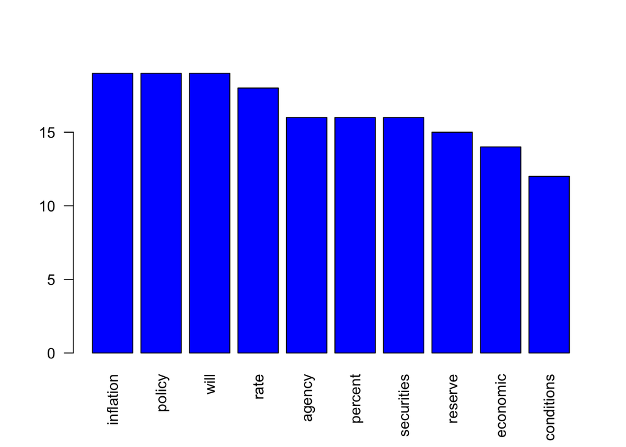

```r
highfreqterms <- rowSums(clean.tdm)
highfreqterms <- sort(highfreqterms, decreasing = TRUE)
barplot(highfreqterms[1:10], col ="blue", las = 2)
```

A more popular visualization method is word cloud, which requires the `wordcloud` library. In a word cloud, the size of a word is relative to its frequency.

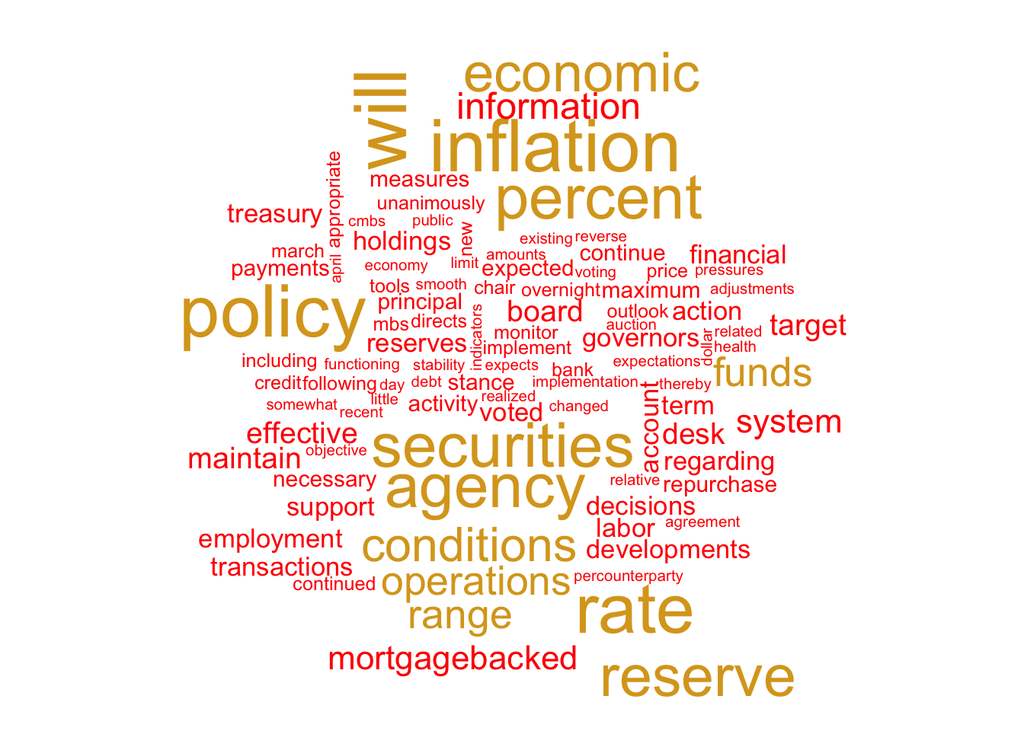

```r
library(wordcloud)
term_vec <- names(highfreqterms)
wordcloud(term_vec, highfreqterms, colors = c("red","goldenrod"), scale = c(3,0.2))
```

We can also plot a comparison cloud, which is simply a word cloud that visualizes dissimilar words across documents:

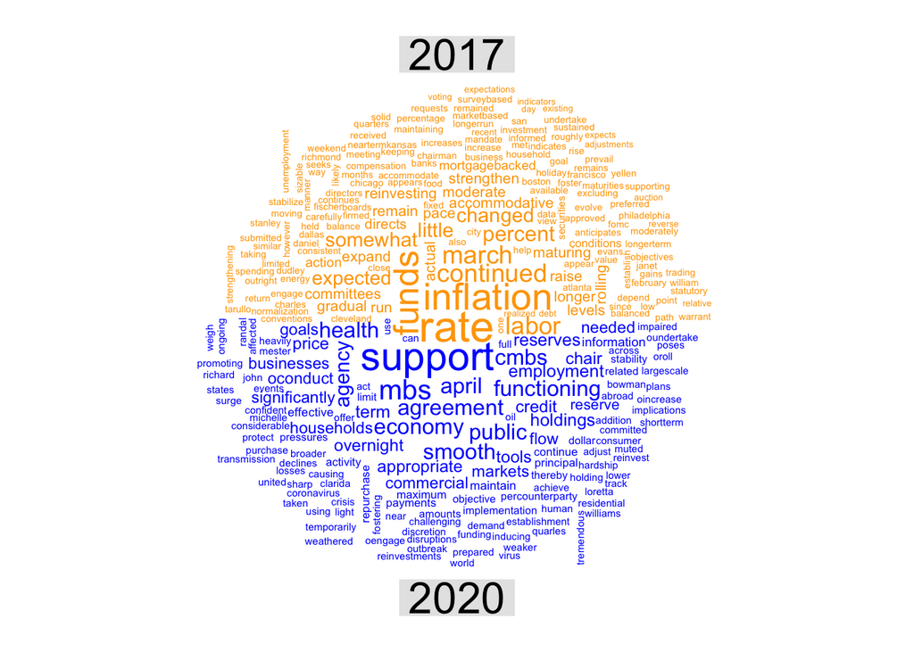

```r
comparison.cloud(clean.tdm, colors = c("orange", "blue"), scale = c(2, 0.2), title.size = 2)
```

Notice how the focus shifts from “inflation” to “support”.

A commonality cloud visualizes shared terms across documents:

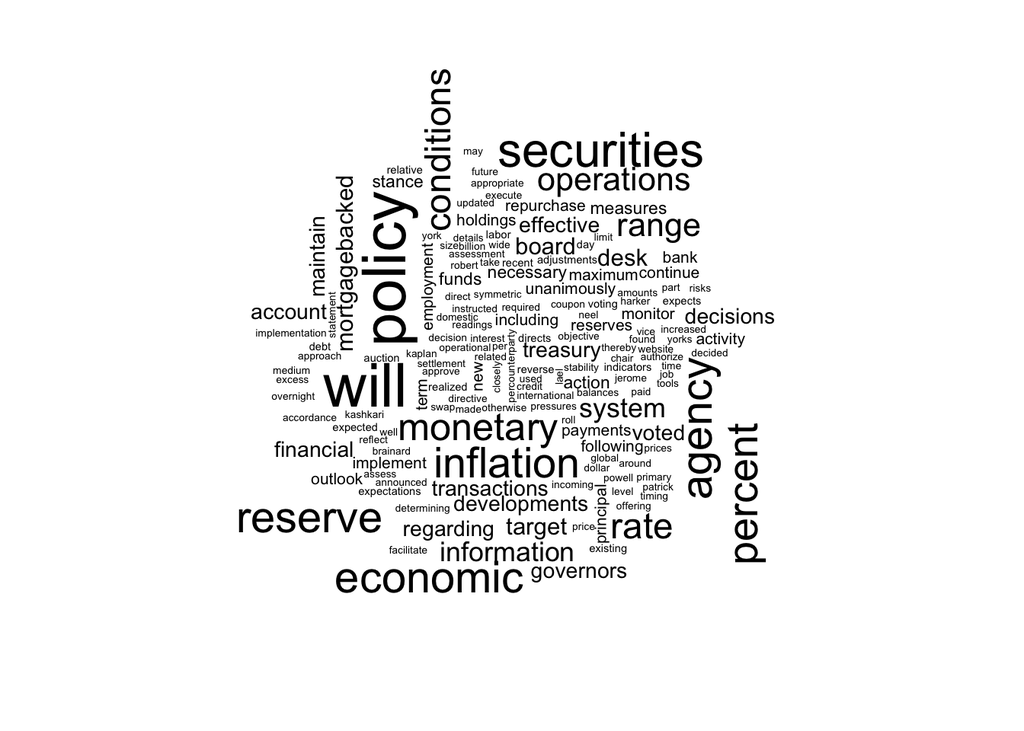

```r
commonality.cloud(clean.tdm, scale = c(2.5, 0.2))
```

# Moving Beyond Single Words

Sometimes it would be better to focus on a group of words rather than one word. Words can have substantially different connotations when combined. For example, if our document involves something like “not beautiful”, then treating the words separately (as *unigrams*) may not be a good idea. We may not want to *tokenize* each term, but to make a *bigram* tokenization. This can be achieved by using the `RWeka::NGramTokenizer()` function:

```r
library(RWeka)
tokenizer <- function(x) {
  NGramTokenizer(x, Weka_control(min=2, max=2))
}

bigram_tdm <- TermDocumentMatrix(FOMC_clean, control = list(tokenize = tokenizer))
bigram_tdm <- as.matrix(bigram_tdm)
head(bigram_tdm)
```

```
##                          Docs
## Terms                     1 2
##   $ billion               1 1
##   abroad significantly    0 1
##   accommodate weekend     1 0
##   accommodative financial 1 0
##   accommodative thereby   1 0
##   accordance following    1 1
```

# TF-IDF: An Alternative Frequency Criterion

Suppose that we have a large corpus containing several documents, but a word appears in each document in a non-random fashion. For example, if we want to examine a set of tweets on US-China affairs, then it is highly likely that the most frequently used terms across the documents in our corpus would be “US” and “China”, which, by themselves, contain no information. This is where *Tf-Idf*, short for *Term Frequency-Inverse Document Frequency*, becomes useful. It is a weighting criterion to be implemented when creating TDMs, which basically imposes a penalty for terms that consistently appear in multiple documents. To implement a Tf-Idf weighting, we can add a control parameter just as we did for bigram tokenization:

```r
tfidf <- TermDocumentMatrix(FOMC_clean, control = list(weighting=weightTfIdf))
tfidf <- as.matrix(tfidf)
head(tfidf)
```

```
##                Docs
## Terms                     1           2
##   abroad        0.000000000 0.002145923
##   accommodate   0.001912046 0.000000000
##   accommodative 0.003824092 0.000000000
##   accordance    0.000000000 0.000000000
##   account       0.000000000 0.000000000
##   achieve       0.000000000 0.002145923
```

We can compare this to the initial TDM:

```r
head(clean.tdm)
```

```
##                Docs
## Terms           2017 2020
##   abroad           0    1
##   accommodate      1    0
##   accommodative    2    0
##   accordance       1    1
##   account          3    3
##   achieve          0    1
```

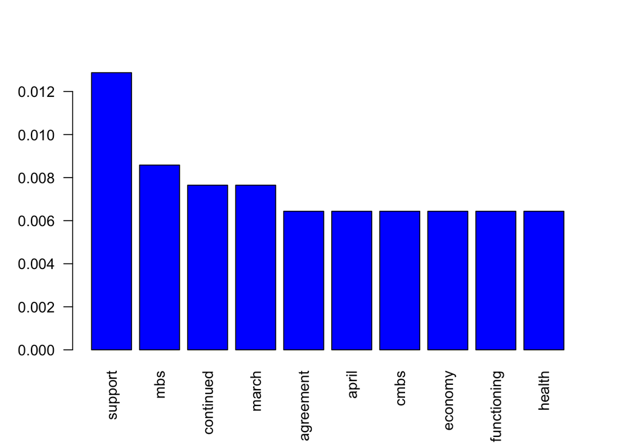

```r
highfreqterms2 <- rowSums(tfidf)
highfreqterms2 <- sort(highfreqterms2, decreasing = TRUE)
barplot(highfreqterms2[1:10], col ="blue", las = 2)
```

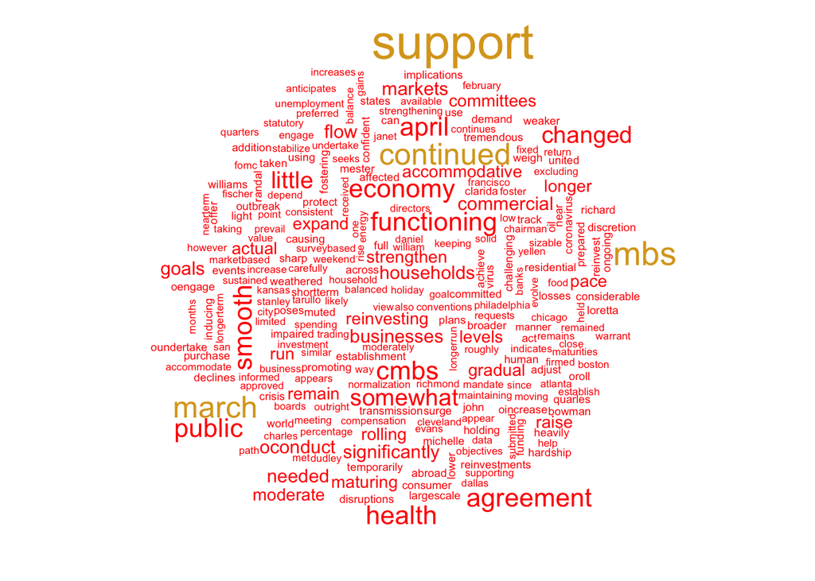

```r
term_vec2 <- names(highfreqterms2)
wordcloud(term_vec2, highfreqterms2, colors = c("red","goldenrod"), scale = c(2.5, 0.2))
```

# Analyzing Texts Written in Turkish

Although English versions of the CBRT Monetary Policy Committee statements are available, we will use the Turkish versions for illustrative purposes.

The FOMC statements were in .docx format, but CBRT Monetary Policy Committee statements are in .pdf format. We can also read pdf files into R. The code chunk below reads one of the MPC statements using `tm::readPDF()` and creates a `VCorpus`. Notice that there is another control parameter, `language = "turkish"`, since the text is in Turkish.

```r
PPK_2016 <- VCorpus(URISource("PPK (04.2016).pdf"), readerControl =
                    list(reader = readPDF, language = "turkish" ))
str(PPK_2016)
```

```
## List of 1
##  $ PPK (04.2016).pdf:List of 2
##   ..$ content: chr [1:6] "                                                                              Sayı: 2016-21\nBASIN DUYURUSU\n26"| __truncated__ "5. Özetle, enflasyon yakın dönemde belirgin bir düşüş sergilemiştir. Temelde işlenmemiş\n    gıda kaynaklı gerç"| __truncated__ "10. 2016 yılı…
##   ..$ meta   :List of 7
##   .. ..$ author       : chr ""
##   .. ..$ datetimestamp: POSIXct[1:1], format: "2016-04-26 13:36:09"
##   .. ..$ description  : chr ""
##   .. ..$ heading      : chr "DUY2016-21"
##   .. ..$ id           : chr "PPK (04.2016).pdf"
##   .. ..$ language     : chr "turkish"
##   .. ..$ origin       : chr "PDFCreator Version 1.5.0"
##   .. ..- attr(*, "class")= chr "TextDocumentMeta"
##   ..- attr(*, "class")= chr [1:2] "PlainTextDocument" "TextDocument"
##  - attr(*, "class")= chr [1:2] "VCorpus" "Corpus"
```

Alternatively, we can use the `tabulizer::extract_text()` function:

```r
library(tabulizer)
PPK_2016_2 <- extract_text("PPK (04.2016).pdf")
PPK_2016_2 <- VCorpus(VectorSource(PPK_2016),
                      readerControl = list (language = "turkish"))
str(PPK_2016_2)
```

```
## List of 1
##  $ 1:List of 2
##   ..$ content: chr [1:6] "                                                                              Sayı: 2016-21\nBASIN DUYURUSU\n26"| __truncated__ "5. Özetle, enflasyon yakın dönemde belirgin bir düşüş sergilemiştir. Temelde işlenmemiş\n    gıda kaynaklı gerç"| __truncated__ "10. 2016 yılı…
##   ..$ meta   :List of 7
##   .. ..$ author       : chr(0)
##   .. ..$ datetimestamp: POSIXlt[1:1], format: "2022-05-24 12:50:37"
##   .. ..$ description  : chr(0)
##   .. ..$ heading      : chr(0)
##   .. ..$ id           : chr "1"
##   .. ..$ language     : chr "turkish"
##   .. ..$ origin       : chr(0)
##   .. ..- attr(*, "class")= chr "TextDocumentMeta"
##   ..- attr(*, "class")= chr [1:2] "PlainTextDocument" "TextDocument"
##  - attr(*, "class")= chr [1:2] "VCorpus" "Corpus"
```

We may also want to read multiple pdf documents into R at once. When the number of documents is very large, reading them one by one can be excruciating. We can simply use the `list.files()` function from base R and then specify the source of our documents with `tm::URISource()` (Uniform Resource Identifier). For example:

```r
(files <- list.files(pattern = "pdf$"))
```

```
## [1] "PPK (04.2016).pdf" "PPK (04.2020).pdf"
```

```r
# It creates a list from the names of the files in the working directory
# $ specifies the end of the file name
```

Then we can create a corpus:

```r
PPK <- VCorpus(URISource(files), readerControl =
                    list(reader = readPDF, language = "turkish" ))
str(PPK)
```

```
## List of 2
##  $ PPK (04.2016).pdf:List of 2
##   ..$ content: chr [1:6] "                                                                              Sayı: 2016-21\nBASIN DUYURUSU\n26"| __truncated__ "5. Özetle, enflasyon yakın dönemde belirgin bir düşüş sergilemiştir. Temelde işlenmemiş\n    gıda kaynaklı gerç"| __truncated__ "10. 2016 yılı…
##   ..$ meta   :List of 7
##   .. ..$ author       : chr ""
##   .. ..$ datetimestamp: POSIXct[1:1], format: "2016-04-26 13:36:09"
##   .. ..$ description  : chr ""
##   .. ..$ heading      : chr "DUY2016-21"
##   .. ..$ id           : chr "PPK (04.2016).pdf"
##   .. ..$ language     : chr "turkish"
##   .. ..$ origin       : chr "PDFCreator Version 1.5.0"
##   .. ..- attr(*, "class")= chr "TextDocumentMeta"
##   ..- attr(*, "class")= chr [1:2] "PlainTextDocument" "TextDocument"
##  $ PPK (04.2020).pdf:List of 2
##   ..$ content: chr [1:4] "" "" "" ""
##   ..$ meta   :List of 7
##   .. ..$ author       : NULL
##   .. ..$ datetimestamp: POSIXct[1:1], format: "2106-02-07 09:28:15"
##   .. ..$ description  : NULL
##   .. ..$ heading      : chr "DUY2020-26"
##   .. ..$ id           : chr "PPK (04.2020).pdf"
##   .. ..$ language     : chr "turkish"
##   .. ..$ origin       : NULL
##   .. ..- attr(*, "class")= chr "TextDocumentMeta"
##   ..- attr(*, "class")= chr [1:2] "PlainTextDocument" "TextDocument"
##  - attr(*, "class")= chr [1:2] "VCorpus" "Corpus"
```

The steps for cleaning and preprocessing is as usual. However, stopwords for the Turkish language is not available in the `tm` library. We will need the `stopwords` package:

```r
library(stopwords)
stopwords = stopwords("turkish", source = "stopwords-iso")

head(stopwords)
```

```
## [1] "acaba"      "acep"       "açıkça"     "açıkçası"   "adamakıllı"
## [6] "adeta"
```

```r
length(stopwords)
```

```
## [1] 471
```

We can now apply the usual transformations:

```r
clean.new.corpus <- function(corpus){
  corpus <- tm_map(corpus, content_transformer(tolower))
  corpus <- tm_map(corpus, removeWords, stopwords)
  corpus <- tm_map(corpus, removeNumbers)
  corpus <- tm_map(corpus, removePunctuation, ucp = TRUE)
  #use unicode character properties to identify punctuations
  corpus <- tm_map(corpus, stripWhitespace)
}

PPK_clean <- clean.new.corpus(PPK)
str(PPK_clean)
```

```
## List of 2
##  $ PPK (04.2016).pdf:List of 2
##   ..$ content: chr [1:6] " sayı basin duyurusu nisan para politikasi kurulu toplanti özeti toplantı tarihi nisan enflasyon gelişmeleri ma"| __truncated__ " özetle enflasyon yakın dönemde belirgin düşüş sergilemiştir temelde işlenmemiş gıda kaynaklı gerçekleşen düşüş"| __truncated__ " yılı ocak dö…
##   ..$ meta   :List of 7
##   .. ..$ author       : chr ""
##   .. ..$ datetimestamp: POSIXct[1:1], format: "2016-04-26 13:36:09"
##   .. ..$ description  : chr ""
##   .. ..$ heading      : chr "DUY2016-21"
##   .. ..$ id           : chr "PPK (04.2016).pdf"
##   .. ..$ language     : chr "turkish"
##   .. ..$ origin       : chr "PDFCreator Version 1.5.0"
##   .. ..- attr(*, "class")= chr "TextDocumentMeta"
##   ..- attr(*, "class")= chr [1:2] "PlainTextDocument" "TextDocument"
##  $ PPK (04.2020).pdf:List of 2
##   ..$ content: chr [1:4] "" "" "" ""
##   ..$ meta   :List of 7
##   .. ..$ author       : NULL
##   .. ..$ datetimestamp: POSIXct[1:1], format: "2106-02-07 09:28:15"
##   .. ..$ description  : NULL
##   .. ..$ heading      : chr "DUY2020-26"
##   .. ..$ id           : chr "PPK (04.2020).pdf"
##   .. ..$ language     : chr "turkish"
##   .. ..$ origin       : NULL
##   .. ..- attr(*, "class")= chr "TextDocumentMeta"
##   ..- attr(*, "class")= chr [1:2] "PlainTextDocument" "TextDocument"
##  - attr(*, "class")= chr [1:2] "VCorpus" "Corpus"
```

Take a closer look at the content of the second document. It seems that it does not contain any textual element. If you pull out the content:

```r
PPK_clean[[2]]$content
```

```
## [1] "" "" "" ""
```

This particular pdf document is a four-pages-long text but in the corpus it has 4 empty character strings. `tm::readPDF()` fails to read it is since the pdf document is nonsearchable (i.e., an image). Fortunately, there is a way to extract text from such files. We can use `tesseract::ocr()` for optical character recognition from images. We should first convert the pdf document to an image format (preferably .png) using `pdftools::pdf_convert()`. The function converts each page in a pdf file to a specified image format:

```r
library(pdftools)
png <- pdf_convert("PPK (04.2020).pdf", format = "png", dpi = 300)
```

```
## Converting page 1 to PPK (04.2020)_1.png... done!
## Converting page 2 to PPK (04.2020)_2.png... done!
## Converting page 3 to PPK (04.2020)_3.png... done!
## Converting page 4 to PPK (04.2020)_4.png... done!
```

Now that each page is converted to .png, we are ready to perform optical character recognition. Luckily, `tesseract` provides an engine that recognizes special Turkish characters.

```r
library(tesseract)
PPK_2020 <- ocr(png, engine = tesseract("tur"))
str(PPK_2020)
```

```
##  chr [1:4] "ye\na Z / (UT TÜRKİYE CUMHURİYET\n1 777 ( B MERKEZ BANKASI\nSi\n\n30 Nisan 2020, Sayı: 2020-26\n\nToplantı Tari"| __truncated__ ...
```

Then simply replace the content of the document:

```r
PPK_clean[[2]]$content <- PPK_2020
str(PPK_clean)
```

```
## List of 2
##  $ PPK (04.2016).pdf:List of 2
##   ..$ content: chr [1:6] " sayı basin duyurusu nisan para politikasi kurulu toplanti özeti toplantı tarihi nisan enflasyon gelişmeleri ma"| __truncated__ " özetle enflasyon yakın dönemde belirgin düşüş sergilemiştir temelde işlenmemiş gıda kaynaklı gerçekleşen düşüş"| __truncated__ " yılı ocak dö…
##   ..$ meta   :List of 7
##   .. ..$ author       : chr ""
##   .. ..$ datetimestamp: POSIXct[1:1], format: "2016-04-26 13:36:09"
##   .. ..$ description  : chr ""
##   .. ..$ heading      : chr "DUY2016-21"
##   .. ..$ id           : chr "PPK (04.2016).pdf"
##   .. ..$ language     : chr "turkish"
##   .. ..$ origin       : chr "PDFCreator Version 1.5.0"
##   .. ..- attr(*, "class")= chr "TextDocumentMeta"
##   ..- attr(*, "class")= chr [1:2] "PlainTextDocument" "TextDocument"
##  $ PPK (04.2020).pdf:List of 2
##   ..$ content: chr [1:4] "ye\na Z / (UT TÜRKİYE CUMHURİYET\n1 777 ( B MERKEZ BANKASI\nSi\n\n30 Nisan 2020, Sayı: 2020-26\n\nToplantı Tari"| __truncated__ "İİ 4 6. Nisan ayında yılsonu enflasyon beklentilerindeki iyileşme sürmüştür. Ancak salgının seyri ile\nRİ Lİ il"| __truncated__ "ji t koşullar…
##   ..$ meta   :List of 7
##   .. ..$ author       : NULL
##   .. ..$ datetimestamp: POSIXct[1:1], format: "2106-02-07 09:28:15"
##   .. ..$ description  : NULL
##   .. ..$ heading      : chr "DUY2020-26"
##   .. ..$ id           : chr "PPK (04.2020).pdf"
##   .. ..$ language     : chr "turkish"
##   .. ..$ origin       : NULL
##   .. ..- attr(*, "class")= chr "TextDocumentMeta"
##   ..- attr(*, "class")= chr [1:2] "PlainTextDocument" "TextDocument"
##  - attr(*, "class")= chr [1:2] "VCorpus" "Corpus"
```

Notice that the content of each document consists of as many character strings as the number of pages in the original pdf document. The final step involves making the content a character vector with a single string which contains the whole text (as we did for FOMC statements). A simple loop will achieve this for each document:

```r
for(i in 1: length(PPK_clean)){
  PPK_clean[[i]]$content <- paste(PPK_clean[[i]]$content, collapse = ' ')
}
str(PPK_clean)
```

```
## List of 2
##  $ PPK (04.2016).pdf:List of 2
##   ..$ content: chr " sayı basin duyurusu nisan para politikasi kurulu toplanti özeti toplantı tarihi nisan enflasyon gelişmeleri ma"| __truncated__
##   ..$ meta   :List of 7
##   .. ..$ author       : chr ""
##   .. ..$ datetimestamp: POSIXct[1:1], format: "2016-04-26 13:36:09"
##   .. ..$ description  : chr ""
##   .. ..$ heading      : chr "DUY2016-21"
##   .. ..$ id           : chr "PPK (04.2016).pdf"
##   .. ..$ language     : chr "turkish"
##   .. ..$ origin       : chr "PDFCreator Version 1.5.0"
##   .. ..- attr(*, "class")= chr "TextDocumentMeta"
##   ..- attr(*, "class")= chr [1:2] "PlainTextDocument" "TextDocument"
##  $ PPK (04.2020).pdf:List of 2
##   ..$ content: chr "ye\na Z / (UT TÜRKİYE CUMHURİYET\n1 777 ( B MERKEZ BANKASI\nSi\n\n30 Nisan 2020, Sayı: 2020-26\n\nToplantı Tari"| __truncated__
##   ..$ meta   :List of 7
##   .. ..$ author       : NULL
##   .. ..$ datetimestamp: POSIXct[1:1], format: "2106-02-07 09:28:15"
##   .. ..$ description  : NULL
##   .. ..$ heading      : chr "DUY2020-26"
##   .. ..$ id           : chr "PPK (04.2020).pdf"
##   .. ..$ language     : chr "turkish"
##   .. ..$ origin       : NULL
##   .. ..- attr(*, "class")= chr "TextDocumentMeta"
##   ..- attr(*, "class")= chr [1:2] "PlainTextDocument" "TextDocument"
##  - attr(*, "class")= chr [1:2] "VCorpus" "Corpus"
```

Finally, reapply the cleaning function:

```r
PPK_clean <- clean.new.corpus(PPK_clean)
str(PPK_clean)
```

```
## List of 2
##  $ PPK (04.2016).pdf:List of 2
##   ..$ content: chr " sayı basin duyurusu nisan para politikasi kurulu toplanti özeti toplantı tarihi nisan enflasyon gelişmeleri ma"| __truncated__
##   ..$ meta   :List of 7
##   .. ..$ author       : chr ""
##   .. ..$ datetimestamp: POSIXct[1:1], format: "2016-04-26 13:36:09"
##   .. ..$ description  : chr ""
##   .. ..$ heading      : chr "DUY2016-21"
##   .. ..$ id           : chr "PPK (04.2016).pdf"
##   .. ..$ language     : chr "turkish"
##   .. ..$ origin       : chr "PDFCreator Version 1.5.0"
##   .. ..- attr(*, "class")= chr "TextDocumentMeta"
##   ..- attr(*, "class")= chr [1:2] "PlainTextDocument" "TextDocument"
##  $ PPK (04.2020).pdf:List of 2
##   ..$ content: chr "ye a z ut türkiye cumhuriyet b merkez bankasi si nisan sayı toplantı tarihi nisan enflasyon gelişmeleri martayı"| __truncated__
##   ..$ meta   :List of 7
##   .. ..$ author       : NULL
##   .. ..$ datetimestamp: POSIXct[1:1], format: "2106-02-07 09:28:15"
##   .. ..$ description  : NULL
##   .. ..$ heading      : chr "DUY2020-26"
##   .. ..$ id           : chr "PPK (04.2020).pdf"
##   .. ..$ language     : chr "turkish"
##   .. ..$ origin       : NULL
##   .. ..- attr(*, "class")= chr "TextDocumentMeta"
##   ..- attr(*, "class")= chr [1:2] "PlainTextDocument" "TextDocument"
##  - attr(*, "class")= chr [1:2] "VCorpus" "Corpus"
```

OCR could not read the TCMB logo on the front page, thus some strange words appear in the first line which need to be removed.

```r
#remove words with length 2 or less
PPK_clean[[2]]$content <- gsub('\\b\\w{1,2}\\b','',PPK_clean[[2]]$content)
str(PPK_clean)
```

```
## List of 2
##  $ PPK (04.2016).pdf:List of 2
##   ..$ content: chr " sayı basin duyurusu nisan para politikasi kurulu toplanti özeti toplantı tarihi nisan enflasyon gelişmeleri ma"| __truncated__
##   ..$ meta   :List of 7
##   .. ..$ author       : chr ""
##   .. ..$ datetimestamp: POSIXct[1:1], format: "2016-04-26 13:36:09"
##   .. ..$ description  : chr ""
##   .. ..$ heading      : chr "DUY2016-21"
##   .. ..$ id           : chr "PPK (04.2016).pdf"
##   .. ..$ language     : chr "turkish"
##   .. ..$ origin       : chr "PDFCreator Version 1.5.0"
##   .. ..- attr(*, "class")= chr "TextDocumentMeta"
##   ..- attr(*, "class")= chr [1:2] "PlainTextDocument" "TextDocument"
##  $ PPK (04.2020).pdf:List of 2
##   ..$ content: chr "    türkiye cumhuriyet  merkez bankasi  nisan sayı toplantı tarihi nisan enflasyon gelişmeleri martayında tüket"| __truncated__
##   ..$ meta   :List of 7
##   .. ..$ author       : NULL
##   .. ..$ datetimestamp: POSIXct[1:1], format: "2106-02-07 09:28:15"
##   .. ..$ description  : NULL
##   .. ..$ heading      : chr "DUY2020-26"
##   .. ..$ id           : chr "PPK (04.2020).pdf"
##   .. ..$ language     : chr "turkish"
##   .. ..$ origin       : NULL
##   .. ..- attr(*, "class")= chr "TextDocumentMeta"
##   ..- attr(*, "class")= chr [1:2] "PlainTextDocument" "TextDocument"
##  - attr(*, "class")= chr [1:2] "VCorpus" "Corpus"
```

Let’s create the TDM and draw some visuals:

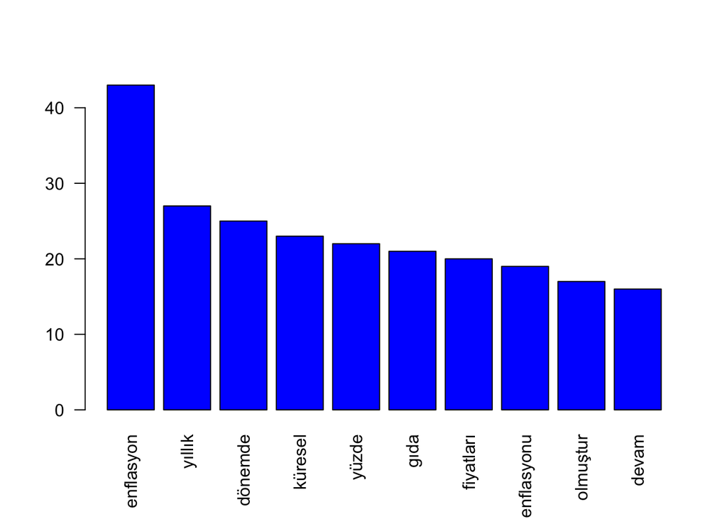

```r
tdmppk <- TermDocumentMatrix(PPK_clean)
tdmppk <- as.matrix(tdmppk)
freqtermsppk <- rowSums(tdmppk)
freqtermsppk <- sort(freqtermsppk, decreasing = TRUE)
barplot(freqtermsppk[1:10], las = 2, col = "blue")
```

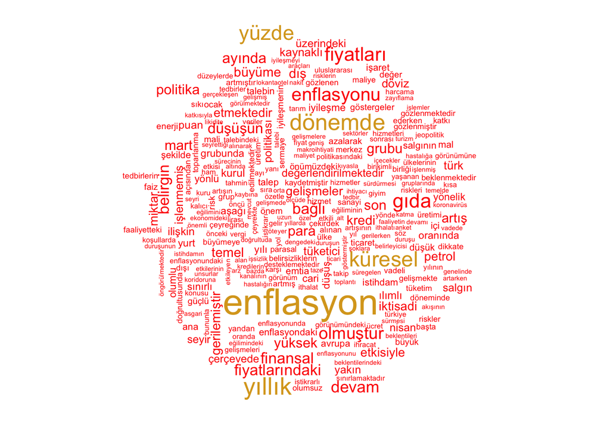

```r
term_vec_ppk <- names(freqtermsppk)
wordcloud(term_vec_ppk, freqtermsppk, colors = c("red","goldenrod"), scale = c(2.5, 0.3))
```

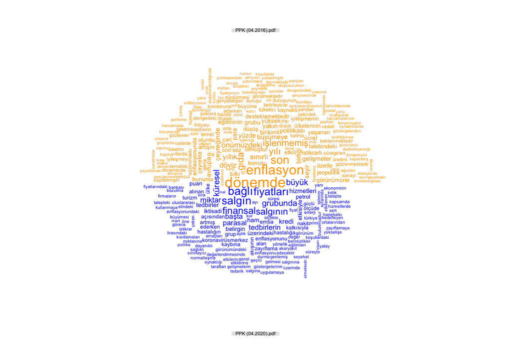

```r
comparison.cloud(tdmppk, colors = c("orange", "blue"),  title.size = 0.4, scale = c(1.2,0.2))
```

# Sentiment Analysis

We can use `SentimentAnalysis::analyzeSentiment()` for sentiment analysis, which aims to assess whether the tone of a document is positive or negative with the help of a predefined dictionary of positive and negative words. The package `SentimentAnalysis`comes with built-in dictionaries. `analyzeSentiment()` takes a string, corpus or a TDM and returns a matrix with calculated sentiment scores based on a set of rules:

```r
library(SentimentAnalysis)
sentiments <- analyzeSentiment(FOMC_clean,
                               rules = list("Overall Score"=list(ruleSentiment,
                                                               loadDictionaryLM()),
                                            "Positivity" = list(rulePositivity,
                                                                  loadDictionaryLM()),
                                            "Negativity" = list(ruleNegativity,
                                                                  loadDictionaryLM()),
                                            "Polarity" = list(ruleSentimentPolarity,
                                                                loadDictionaryLM())),
                               stemming = TRUE)
sentiments
```

```
##   Overall Score Positivity Negativity    Polarity
## 1  -0.005736138 0.02868069 0.03441683 -0.09090909
## 2  -0.017167382 0.03648069 0.05364807 -0.19047619
```

Sentiment scores are obtained using the Loughran-McDonald dictionary (2011), which was specifically created for the analysis of financial texts. The overall sentiment score is calculated as the ratio of the difference between positive and negative word counts to the total number of words. Positivity is the proportion of words that are labeled as positive and negativity is the proportion of words that are labeled as negative. Finally, polarity is the difference between positive and negative words divided by their sum. All of these scores are calculated for each document. Alternatively, not specifying a rule list in the function will return sentiment scores based on all available dictionaries. For example:

```r
sentimentsall <- analyzeSentiment(FOMC_clean, stemming = TRUE)
sentimentsall
```

```
##   WordCount SentimentGI NegativityGI PositivityGI  SentimentHE NegativityHE
## 1       523   0.1357553   0.07456979     0.210325  0.015296367  0.003824092
## 2       466   0.1545064   0.06866953     0.223176 -0.004291845  0.008583691
##   PositivityHE  SentimentLM NegativityLM PositivityLM RatioUncertaintyLM
## 1  0.019120459 -0.005736138   0.03441683   0.02868069         0.03250478
## 2  0.004291845 -0.017167382   0.05364807   0.03648069         0.01716738
##   SentimentQDAP NegativityQDAP PositivityQDAP
## 1     0.1051625     0.04588910      0.1510516
## 2     0.1223176     0.05364807      0.1759657
```

We can also examine the sentiment in the CBRT Monetary Policy Committee statements. However, we need a custom dictionary since there are no available Turkish dictionaries in the `SentimentAnalysis` package. We can use the Google Translated version of the LM dictionary as a first step.

```r
library(readxl)
turkish_neg <- read_xlsx("LM-turkish.xlsx", sheet = 1, col_names = FALSE)
turkish_pos <- read_xlsx("LM-turkish.xlsx", sheet = 2, col_names = FALSE)
turkish_neg <- as.character(turkish_neg$...1)
turkish_pos <- as.character(turkish_pos$...1)

str(turkish_neg)
```

```
##  chr [1:2351] "terk etmek" "terk edilmiş" "terk edilmesi" "terk" ...
```

```r
str(turkish_pos)
```

```
##  chr [1:347] "yapabilmek" "bolluk" "bol" "takip edildi" "başarmak" ...
```

We should create our custom dictionary with the `SentimentAnalysis::SentimentDictionaryBinary()` function, which creates a new object with two separate vectors of positive and negative words. The calculation rules require that the dictionary be this type of object, otherwise sentiment scores cannot be calculated.

```r
dict <- SentimentDictionaryBinary(turkish_pos, turkish_neg)
str(dict)
```

```
## List of 2
##  $ positiveWords: chr [1:347] "yapabilmek" "bolluk" "bol" "takip edildi" ...
##  $ negativeWords: chr [1:2351] "terk etmek" "terk edilmiş" "terk edilmesi" "terk" ...
##  - attr(*, "class")= chr "SentimentDictionaryBinary"
```

Notice that there are bigrams among positive and negative words, which is the downside of working with a google-translated dictionary. As we will see, the number of words identified as positive or negative are going to be much lower.

Now we are ready to calculate sentiment scores:

```r
sentiment_tr <- analyzeSentiment(PPK_clean,
                                 rules = list("Words" = list(ruleWordCount),
                                            "Positivity" = list(rulePositivity,
                                                                dict),
                                            "Negativity" = list(ruleNegativity,
                                                                dict),
                                            "Overall" = list(ruleSentiment,
                                                                dict),
                                            "Polarity" = list(ruleSentimentPolarity,
                                                                dict)),
stemming = TRUE)

sentiment_tr
```

```
##   Words Positivity Negativity     Overall   Polarity
## 1  1489 0.01007388 0.04499664 -0.03492277 -0.6341463
## 2  1307 0.01683244 0.05508799 -0.03825555 -0.5319149
```

We can simply multiply the total number of words in each document with their respective positivity and negativity scores to find out how many words matched with those classified as positive or negative in the LM dictionary. For instance, there are 1489 total words in the 2016 statement, and $1489 \times 0.01 \approx 15$ positive words are identified. Likewise, there are $1489 \times 0.044 \approx 67$ negative words. For the 2020 statement, the number of positive words and negative words are $1307 \times 0.016 \approx 22$ and $1307 \times 0.055 \approx 72$, respectively.

Overall, a more negative tone is present in the 2020 MPC statement, although overall sentiment scores are quite close to each other. On the other hand, polarity scores, which are not sensitive to document length, imply a more negative tone in the 2016 statement. This is due to a slightly higher gap between the number of positive and negative words used in the 2016 statement: $67 - 15 = 52$. For 2020, the difference is $72 - 22 = 50$. Coupled with a lower number of total positive and negative words, the resulting polarity score is substantially larger for 2016.